# Análisis de Enlaces Web

# Segundo Análisis

## Sección 2.1 - Página Principal

Data Analysis module allows the user to have a preliminary analysis for quality control based on the data distribution per sample, using plots below

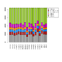

*Fig. 1. CPM, Counts Per Million Plot*

The Count per million (CPM) plot shows the number of genes within each sample having more than 0 CPM, or more than 1, 2, 5 and 10 CPM. This plot could help the user decide the threshold to remove genes that appear to be very lowly expressed in any of the experimental conditions.

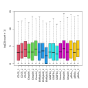

*Fig. 2. Boxplot with pseudo counts*

Samples boxplot provides an easy way to visualize the distribution of pseudocounts in each sample, since it shows statistical measures such as median, quartiles, minimum and maximum. Whiskers are also drawn extending beyond each end of the box with points beyond the whiskers typically indicating outliers.

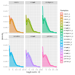

*Fig. 3. Density plot*

Pseudocounts distributions can also be summarized by means of a density plot. Density plot provides more detail by enabling, for example, the detection of dissimilarity in replicates’ behavior.

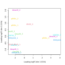

*Fig. 4. Multi-dimensional scaling plot*

Multidimensional Scaling (MDS) is a technique that is used to create a visual representation of the pattern of proximities (similarities, dissimilarities, or distances) among a set of objects. In the context of RNA-Seq analysis, MDS plot shows variation among RNA-seq samples, distance between sample labels indicates dissimilarity.

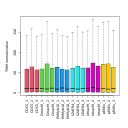

*Fig. 6. Boxplot of standardized counts with TMM*

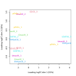

*Fig. 7. Multi-dimensional scaling plot of standardized counts with TMM*

This type of graph is useful for visualizing the overall effect of experimental covariances and their batch effects. When a pair of samples, under the same condition, tend to group together, a lot effect can be suspected.

From this point, the same graphs are replicated, but they show the raw counts normalized with the TMM method (Trimmed Mean of M-values), (1) Robinson.

## Sección 2.2 - EdgeR.php

In this section, we present the results of the differential expression analysis generated by the edgeR method. (1)

### Gene Expression Plots

In the context of RNA-Seq analysis, MDS plot shows variation among RNA-seq samples, with the distance between sample labels indicating dissimilarity. When the experiment is well controlled, the greatest sources of variation should correspond to the treatments/groups of interest.

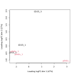

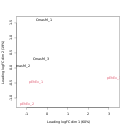

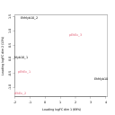

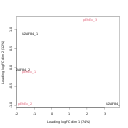

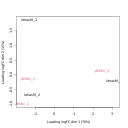

## Sección 3 - DESeq2.php

### DESeq2 Results

Diferential Expression by DESeq2. (1)

The following text files (can be opened in Excel) they contains the result of differential expression analysis for all genes with significant counts. The meaning of e ach column is described below.

1. id : The first column is the id(gene, transcript, etc.)
2. baseMean: Mean normalised counts, averaged over all samples from the two conditions
3. log2FoldChange : logaritmo de la magnitud de cambio entre el par de condiciones, en la tercer columna
4. lfcSE: Standard errors of logarithm fold change
5. Stat: test statistics
6. pvalue: p value for the statistical significance of this change
7. padj: p value adjusted for multiple testing with the Benjamini-Hochberg procedure The last columns correspond to:
8. raw counts: Raw counts for all sample
9. normalized counts: Normalized counts for all samples
10. Regulation : gene regulation, indicating how and in which condition the genes was expressed

pval files

- `pEhExvsCDC5_pval.txt`
- `pEhExvsCmasM_pval.txt`
- `pEhExvsEhMyb10_pval.txt`
- `pEhExvsU2AF84_pval.txt`
- `pEhExvsUmasM_pval.txt`

Abundance files

- `pEhExvsCDC5_Abundances.txt`
- `pEhExvsCmasM_Abundances.txt`
- `pEhExvsEhMyb10_Abundances.txt`
- `pEhExvsU2AF84_Abundances.txt`
- `pEhExvsUmasM_Abundances.txt`

logFC files

- `pEhExvsCDC5_logFC.txt`
- `pEhExvsCmasM_logFC.txt`
- `pEhExvsEhMyb10_logFC.txt`
- `pEhExvsUmasM_logFC.txt`
- `pEhExvsU2AF84_logFC.txt`

Other files

- `pEhExvsCDC5.txt`
- `pEhExvsCmasM.txt`
- `pEhExvsEhMyb10.txt`
- `pEhExvsU2AF84.txt`
- `pEhExvsUmasM.txt`

The following files with TOP.txt ending, it are subgroup of previos files, and it containing DE results only of the differentially expressed genes (considering the established cutoff parameters).

- `pEhExvsCDC5_TOP.txt`
- `pEhExvsCmasM_TOP.txt`
- `pEhExvsEhMyb10_TOP.txt`
- `pEhExvsU2AF84_TOP.txt`
- `pEhExvsUmasM_TOP.txt`

The following files have genes that it was reported as differential expressed for more than one method (DESeq2 + other)

- `pEhExvsCDC5_Intersect.txt`
- `pEhExvsEhMyb10_Intersect.txt`
- `pEhExvsCmasM_Intersect.txt`
- `pEhExvsU2AF84_Intersect.txt`

### Graficas

plotPCA.pdfThis type of plot is useful for visualizing the overall effect of experimental covariates and batch effects (Love MI 2014).

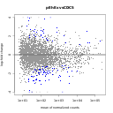

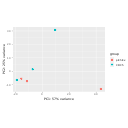

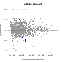

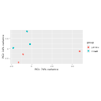

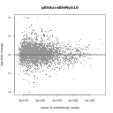

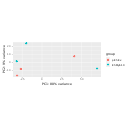

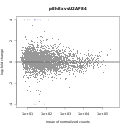

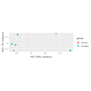

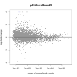

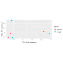